# Problem Set 5, due June 1 at 11:59 pm.

As usual, you are highly encouraged to *start this problem set early!* My best guess (no guarantees!) is that Part 1 will be conceptually easy but perhaps time consuming. Parts 2 and 3 are medium difficult, but there are plenty of opportunities to get confused with python data structures, so if you're going to get stuck, get stuck (and unstuck) early! Part 4 will give you an opportunity to get some intuition with PCA.

Note that the two extra credit problems have the potential to be quite challenging and time consuming. Make sure to do everything else in the problem set before you tackle the extra credit.

To get started, download the files "reviews.csv" and "movies.dat" from Canvas.

For this assignment, the following libraries may be useful:

- [numpy](http://docs.scipy.org/doc/numpy-dev/user/index.html), for arrays
- [scikit-learn](http://scikit-learn.org/stable/), for machine learning
- [pandas](http://pandas.pydata.org/), for data frames
- [matplotlib](http://matplotlib.org/), for plotting

In particular, I suggest you familiarize yourself with the following aspects of these libraries, which are not required but which might make your life easier:

- `DataFrame` and other basic [data structures](http://pandas.pydata.org/pandas-docs/stable/dsintro.html) in pandas
- [`groupby`](http://pandas.pydata.org/pandas-docs/stable/groupby.html), `unique`, and other simple aggregation functions
- [`CountVectorizer`](http://scikit-learn.org/stable/modules/generated/sklearn.feature_extraction.text.CountVectorizer.html) for working with text in sklearn.
- [`MultinomialNB`](http://scikit-learn.org/stable/modules/generated/sklearn.naive_bayes.MultinomialNB.html) for Naive Bayes
- Simple tools for [Cross-Validation](http://scikit-learn.org/stable/modules/cross_validation.html) in sklearn

Make sure they load properly with the following code block:

```python
%matplotlib inline
import pandas as pd
import numpy as np
import matplotlib.pyplot as plt

#hint: Consult the scikit-learn documentation to
#      learn about what these classes do do
from  sklearn.cross_validation import cross_val_score
from sklearn.cross_validation import train_test_split
from sklearn.naive_bayes import MultinomialNB
from sklearn.feature_extraction.text import CountVectorizer
import statsmodels.formula.api as smf
from sklearn.metrics import mean_squared_error
from sklearn.preprocessing import StandardScaler
from sklearn.decomposition import PCA
```

## Introduction to the assignment

If you've never seen Rotten Tomatoes before, go spend a few minutes familiarizing yourself with the website. It's a meta-review website that aggregates movie reviews from a large number of critics. Here's what the page for this year's likely [Oscar winner](http://www.rottentomatoes.com/m/the_revenant_2015/) looks like. Note in particular the section on "Critic Reviews" at the bottom -- that's the content that has been scraped and put in the reviews.csv file. Also note that each movie is given a quantitative score on the Tomatometer which is used to classify the movie as either Fresh (good) or Rotten (bad).

Your mission is to develop a classifier to determine whether a movie is Fresh or Rotten based on the contents of the reviews given to the movie. As usual, we'll start out with some exploratory data analysis.

## Part 1: Descriptive analysis

Before beginning the "real" work, dig into the data a bit do see what you're dealing with. Begin by loading the datasets and dropping rows that have missing data:

```python
reviews = pd.read_csv('D:\\OneDrive\\University of Washington Seattle\\Year 3 Quarter 3 (Spring)\\INFO 371\\Problem Sets\\PS5\\reviews.csv')
movies = pd.read_csv('D:\\OneDrive\\University of Washington Seattle\\Year 3 Quarter 3 (Spring)\\INFO 371\\Problem Sets\\PS5\\movies.dat', delimiter='\t')


reviews = reviews[~reviews.quote.isnull()]
reviews = reviews[reviews.fresh != 'none']
reviews = reviews[reviews.quote.str.len() > 0]
```

### 1.1: Basic features of the dataset

Answer the following questions by having your python code directly print the answers:

- How many unique reviews (quotes) are in the `reviews` dataset?
- How many unique reviewers (critics) are in the `reviews` dataset?
- How many unique movies are in the `reviews` dataset?
- How many unique movies are in the *`movies`* dataset?
- How many different publications have reviews in the `reviews` dataset?

```python
reviews["critic+pub"] = reviews["critic"] + '-' + reviews["publication"]
```

```python
#I'm asusming that the same publication does not have two critics with the same first and last name, but different publications can.
#Assuming no two publications share the same name

print("Number of reviews: %i" % len(reviews))
print("Number of unique reviews: %i" % len(reviews['quote'].unique()))
print("Number of movie reviewers: %i" % len(reviews['critic+pub'].unique()))
print("Number of movies in reviews dataset: %i" % len(reviews['rtid'].unique()))
print("Number of movies in movies dataset: %i" % len(movies['imdbID'].unique()))
print("Number of publications: %i" % len(reviews['publication'].unique()))

#print(reviews)
#print(movies)
```

```
Number of reviews: 13419
Number of unique reviews: 12814
Number of movie reviewers: 595
Number of movies in reviews dataset: 1720
Number of movies in movies dataset: 9423
Number of publications: 64
```

### 1.2 Number of reviews per reviewer

Using the `reviews` dataset, create a histogram showing the distribution of the number of reviews per reviewer. Create the bin width (x-axis) to be 1 unit wide, and the range of the axis to be from 0 to 30. Scale the y-axis to show the logarithm of (count of) the number of reviews. Label your axes and make your histogram look professional.

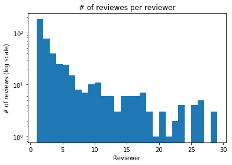

```python
reviews_critic = ((reviews["critic"].value_counts().to_frame().reset_index()))
reviews_critic.columns = ['Name', 'Number']
reviews_critic = reviews_critic.sort_values('Number',ascending = False)

plt.yscale('log')
plt.ylabel('# of reviews (log scale)')
plt.xlabel('Reviewer')
plt.title('# of reviewes per reviewer')
plt.hist(reviews_critic['Number'], bins=np.arange(1,30,1))
plt.show()
```

```python
#Scratch and development code for 1.2
#print(reviews)
#crit_unique = reviews[["critic+pub"]]
#crit_unique.groupby("critic+pub").sum()
#plt.hist(crit_unique, bins=30)

#reviews_critic = ((reviews["critic"].value_counts().to_frame().reset_index()))
#reviews_critic.columns = ['Name', 'Number']
#plt.hist(reviews_critic, bins=30)
#reviews_critic
reviews.loc[0, 'publication']
```

```
'Time Out'
```

### 1.3 Zoom in on a few reviewers

Find the 30 critics with the most reviews, and list their names in a table along with (a) the name of the publication they work for, (b) the date of their first review, and (c) the date of their last review

*hint: use the groupby function to do this quickly*

```python
#Collapse on name and add count on how many times name appears; # of times name appears = # of reviews
#After this, sort by number of reviews and select the top 30 rows
reviews_critic = ((reviews["critic"].value_counts().to_frame().reset_index()))
reviews_critic.columns = ['Name', 'Number of Reviews']
reviews_critic.sort_values('Number of Reviews',ascending = False)
reviews_critic_30 = reviews_critic.head(30)
publisher = [None]*30
first_date = [None]*30
last_date = [None]*30



#for each row in the top 30 critics dataframe,
#  find the corresponding set of rows in the reviews dataframe
#  for the resulting rows, find the publisher (first cell), and first and last dates
#  append these values in a list
#
#after for loop, add this list to the top 30 critics dataframe and print it
for i in range(0, 30):
    name = reviews_critic_30.loc[i, 'Name']
    critic_df = (reviews[(reviews['critic'] == name)])

    first_date_value = critic_df['review_date'].min()
    last_date_value = critic_df['review_date'].max()
    publisher_value = critic_df.loc[critic_df.index[0], 'publication']

    first_date[i] = first_date_value
    last_date[i] = last_date_value
    publisher[i] = publisher_value

reviews_critic_30['Publisher'] = publisher
reviews_critic_30['Date of first review'] = first_date
reviews_critic_30['Date of last review'] = last_date

reviews_critic_30
```

|  | Name | Number of Reviews | Publisher | Date of first review | Date of last review |
| --- | --- | --- | --- | --- | --- |
| 0 | Roger Ebert | 1150 | Chicago Sun-Times | 2000-01-01 00:00:00 | 2013-06-11 00:00:00 |
| 1 | James Berardinelli | 833 | ReelViews | 1800-01-01 00:00:00 | 2012-02-07 00:00:00 |
| 2 | Janet Maslin | 526 | New York Times | 2000-01-01 00:00:00 | 2010-09-07 00:00:00 |
| 3 | Variety Staff | 449 | Variety | 2001-02-13 00:00:00 | 2012-08-15 00:00:00 |
| 4 | Jonathan Rosenbaum | 420 | Chicago Reader | 1988-07-11 00:00:00 | 2013-10-22 00:00:00 |
| 5 | Desson Thomson | 373 | Washington Post | 2000-01-01 00:00:00 | 2012-10-08 00:00:00 |
| 6 | Geoff Andrew | 361 | Time Out | 2005-08-11 00:00:00 | 2012-04-05 00:00:00 |
| 7 | Dave Kehr | 360 | Chicago Reader | 2000-01-01 00:00:00 | 2013-11-20 00:00:00 |
| 8 | Kenneth Turan | 282 | Los Angeles Times | 2000-01-01 00:00:00 | 2013-10-05 00:00:00 |
| 9 | Mick LaSalle | 280 | San Francisco Chronicle | 2000-01-01 00:00:00 | 2009-11-25 00:00:00 |
| 10 | Owen Gleiberman | 241 | Entertainment Weekly | 1800-01-01 00:00:00 | 2011-09-07 00:00:00 |
| 11 | Rita Kempley | 236 | Washington Post | 2000-01-01 00:00:00 | 2013-11-02 00:00:00 |
| 12 | Joe Baltake | 231 | Sacramento Bee | 2000-01-01 00:00:00 | 2013-08-04 00:00:00 |
| 13 | Todd McCarthy | 223 | Variety | 2000-01-01 00:00:00 | 2012-10-09 00:00:00 |
| 14 | Vincent Canby | 207 | New York Times | 2000-01-01 00:00:00 | 2013-07-29 00:00:00 |
| 15 | Hal Hinson | 174 | Washington Post | 2000-01-01 00:00:00 | 2013-06-26 00:00:00 |
| 16 | Susan Stark | 167 | Detroit News | 2000-01-01 00:00:00 | 2002-10-25 00:00:00 |
| 17 | Stephen Holden | 166 | New York Times | 2000-01-01 00:00:00 | 2009-02-06 00:00:00 |
| 18 | Derek Adams | 154 | Time Out | 2006-01-26 00:00:00 | 2009-10-04 00:00:00 |
| 19 | Kevin Thomas | 145 | Los Angeles Times | 2000-01-01 00:00:00 | 2013-11-02 00:00:00 |
| 20 | Peter Stack | 138 | San Francisco Chronicle | 2000-01-01 00:00:00 | 2002-06-18 00:00:00 |
| 21 | Bosley Crowther | 137 | New York Times | 2000-01-01 00:00:00 | 2008-05-06 00:00:00 |
| 22 | Rick Groen | 129 | Globe and Mail | 2002-03-19 00:00:00 | 2009-08-14 00:00:00 |
| 23 | Edward Guthmann | 121 | San Francisco Chronicle | 2000-01-01 00:00:00 | 2003-04-04 00:00:00 |
| 24 | Lisa Schwarzbaum | 117 | Entertainment Weekly | 1979-01-01 00:00:00 | 2012-08-15 00:00:00 |
| 25 | Liam Lacey | 111 | Globe and Mail | 2001-08-24 00:00:00 | 2012-04-04 00:00:00 |
| 26 | Emanuel Levy | 110 | Variety | 2000-01-01 00:00:00 | 2010-08-06 00:00:00 |
| 27 | Richard Schickel | 106 | TIME Magazine | 2000-01-01 00:00:00 | 2013-08-05 00:00:00 |
| 28 | Richard Corliss | 104 | TIME Magazine | 2003-12-16 00:00:00 | 2013-11-06 00:00:00 |
| 29 | Michael Wilmington | 103 | Chicago Tribune | 2000-01-01 00:00:00 | 2013-11-21 00:00:00 |

### 1.4 Ratings over time

(modified to be list of steps for milestone purposes) Using the `movies` dataset, create a plot that shows how the average rating per movie (rtAllCriticsRating) has evolved over time.

Do this by

1. creating a scatterplot where the x-axis is the year in which the movie was released and the y-axis is rtAllCriticsRating.
2. Drop movies with 0 or unknown values to avoid biasing your results.
3. Then, create a scatterplot that has one <year,rating> point for each remaining movie, and pick an appropriate size/color/transparency for these points to ensure that the graph looks professional. In other words, do not simply use the default settings, as this will produce a dense mess of dots that will be hard to interpret.
4. Finally, overlay on this scatterplot a line graph in orange showing how the average movie rating (the average of rtAllCriticsRating across all movies in a year) has changed over time.

Do you notice a trend? What do you think it means?

```
<function matplotlib.pyplot.show>
```

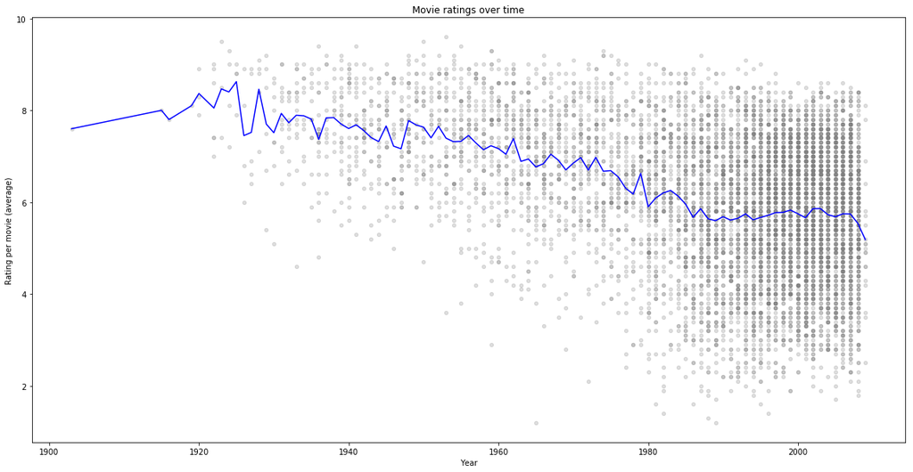

```python
#Removing movies with scores of 0
movies_no0 = movies
movies_no0['rtAllCriticsRating'] = pd.to_numeric(movies_no0['rtAllCriticsRating'], errors='coerce')
movies_no0 = movies_no0[movies_no0['rtAllCriticsRating'] > 0]
#print(movies_no0)

movies_no0_avg = movies_no0.groupby('year').mean().reset_index()
#print(movies_no0_avg)

#Display and graphics settings
plt.figure(figsize=(20,10))
plt.ylabel('Rating per movie (average)')
plt.xlabel('Year')
plt.title('Movie ratings over time')

plt.scatter(movies_no0['year'], movies_no0['rtAllCriticsRating'], s = 20, alpha = 0.25, color='gray')
plt.plot(movies_no0_avg['year'], movies_no0_avg['rtAllCriticsRating'], color='blue')
plt.show
```

The yearly average ratings for the entirety of movies released in a corresponding timeperiod seem to decrease over time. This could be because the accessibility to cameras means making movies isn't just restricted to large studios, but the average Joe who doesn't put out movies that people appreciate or like, giving them low ratings and dragging the overall score for a given year down. It could also however, be indicative of either the overall trend of movie qualities declining, or rather- we, as the audience, being more picky about what we like and don't.

## Part 2: Naive Bayes

Now it gets fun! You are going to use a [Naive Bayes classifier](https://en.wikipedia.org/wiki/Naive_Bayes_classifier) to build a prediction model for whether a review is fresh or rotten, depending on the text of the review. Review the assigned readings on Canvas, as well as the relevant lecture notes before embarking on this journey.

### Using CountVectorizer

One thing that may help you in the following problems is the [CountVectorizer](http://scikit-learn.org/stable/modules/generated/sklearn.feature_extraction.text.CountVectorizer.html) object in Scikit-learn. This will help you convert your raw text fields into "bag of words" vectors, i.e. a data structure that tells you how many times a particular word appears in a blurb. Here's a simple example, make sure you understand what's going on!

```python
from sklearn.feature_extraction.text import CountVectorizer

text = ['machine learning rocks', 'machine learning rules', 'rocks rocks rules']
print("Original text is\n", '\n'.join(text))

vectorizer = CountVectorizer(min_df=0)

# call `fit` to build the vocabulary
vectorizer.fit(text)

# call `transform` to convert text to a bag of words
x = vectorizer.transform(text)

# CountVectorizer uses a sparse array to save memory, but it's easier in this assignment to
# convert back to a "normal" numpy array
x = x.toarray()

print
print("Transformed text vector is \n", x)

# `get_feature_names` tracks which word is associated with each column of the transformed x
print
print("Words for each feature:")
print(vectorizer.get_feature_names())
```

```
Original text is
 machine learning rocks
machine learning rules
rocks rocks rules
Transformed text vector is
 [[1 1 1 0]
 [1 1 0 1]
 [0 0 2 1]]
Words for each feature:
['learning', 'machine', 'rocks', 'rules']
```

### 2.1 Create your X input and Y output

Using the `reviews` dataframe, compute a pair of numerical X, Y arrays where:

- X is a `(nreview, nwords)` array. Each row corresponds to a bag-of-words representation for a single review. This will be the *input* to your model.
- Y is a `nreview`-element 1/0 array, encoding whether a review is Fresh (1) or Rotten (0). This is the desired *output* from your model.

Make sure to remove items with no review text

```python
"""
Function
--------
make_xy

Build a bag-of-words training set for the review data

Parameters
-----------
reviews : Pandas DataFrame
    The review data from above

vectorizer : CountVectorizer object (optional)
    A CountVectorizer object to use. If None,
    then create and fit a new CountVectorizer.
    Otherwise, re-fit the provided CountVectorizer
    using the reviews data

Returns
-------
X : numpy array (dims: nreview, nwords)
    Bag-of-words representation for each review.
Y : numpy array (dims: nreview)
    1/0 array. 1 = fresh review, 0 = rotten review

Examples
--------
X, Y = make_xy(reviews)

1. If vectorizer field none; create vectorizer object
2. If no review text, remove somehow
3. Fit vectorizer to review quote
4. Return array, binary flag
"""

def make_xy(reviews, vectorizer=None):
    if vectorizer == None:
        vectorizer = CountVectorizer()
    vector = vectorizer.fit(reviews.quote)
    vector_trans = vectorizer.transform(reviews.quote)
    X = vector_trans.toarray()
    Y = (reviews.fresh == 'fresh') + 0
    return X, Y
```

```python
train, test = make_xy(reviews)
```

### 2.2 Test-Train split

Next, randomly split the data into two groups: a training set and a validation set. You can do this manually, as you did in the prior problem set. Or, use [`train_test_split`](http://scikit-learn.org/stable/modules/generated/sklearn.cross_validation.train_test_split.html) to do this auto-magically. See [this guide](http://scikit-learn.org/stable/modules/cross_validation.html) for a simple example of how `train_test_split` works.

```python
#Code references linked guide; split on 80%; using guide's random_state
#Note to self; X_train and y_train are same group; identifier- TRAIN, not X, Y
X_train, X_test, y_train, y_test =  train_test_split(train, test, train_size = 0.8)
```

### 2.3 Naive Bayes with `MultinomialNB`

Use the training set to train a Naive Bayes classifier using the [`MultinomialNB`](http://scikit-learn.org/stable/modules/generated/sklearn.naive_bayes.MultinomialNB.html) object. Report the accuracy of this model on both the training and testing data. What do you observe? Interpret these results!

*Hint: This shouldn't take more than 5-10 lines of code to accomplish*

```python
# call the fitted model fitted_model, for future reference:
from sklearn.naive_bayes import MultinomialNB
fitted_model = MultinomialNB()

fitted_model.fit(X = X_train, y = y_train)

train_prediction = fitted_model.predict(X_train)
test_prediction = fitted_model.predict(X_test)

#accuracy_score(y_true, y_pred)
print('Accuracy on training data: ', (1-abs(train_prediction - y_train).sum()/len(y_train))*100,'%')
print('Accuracy on testing data: ', (1-abs(test_prediction - y_test).sum()/len(y_train))*100,'%')
```

```
Accuracy on training data:  92.23102002794597 %
Accuracy on testing data:  94.33628318584071 %
```

### 2.4 (EXTRA CREDIT) Naive Bayes from Scratch!

That was almost too easy, right? Right.

Your next mission, should you choose to accept it, is to write your own Naive Bayes classifier without relying on `MultinomialNB` or a similar pre-written package. In addition to the lecture notes and assigned readings, I highly recommend that you review Michael Collin’s lecture notes on Naïve Bayes before starting (available on Canvas).

**Note:** You should do this extra credit assignment *after* you have finished the rest of the problem set. It is very rewarding, but can also be quite time-consuming!

*Hint: You will benefit most from this exercise if you attempt to write the algorithm directly from the lecture notes. That said, if you really get stuck, Krishnamurthy Viswanathan has written a simple version of [NB in python](http://ebiquity.umbc.edu/blogger/2010/12/07/naive-bayes-classifier-in-50-lines/), which you can peek at if you really get stuck.*

```python
# Your code here
```

## Part 3: Evaluation

### 3.1 Estimate the likelihood of your data

Given a fitted model, you can compute the log-likelihood of your data as a way to assess the performance of your model. Using `fitted_model.predict_logproba`, the idea is to write a function that computes the log-likelihood of a dataset, so that we can inspect the log-likelihood of your training and testing data given your fitted model from part 2.

To help you out a little bit, we'll do this part for you. But make sure you understand it, because you'll need to use this later!

```python
"""
Function
--------
log_likelihood

Compute the log likelihood of a dataset according to a bayesian classifier.
The Log Likelihood is defined by

L = Sum_fresh(logP(fresh)) + Sum_rotten(logP(rotten))

Where Sum_fresh indicates a sum over all fresh reviews,
and Sum_rotten indicates a sum over rotten reviews

Parameters
----------
model : Bayesian classifier
x : (nexample, nfeature) array
    The input data
y : (nexample) integer array
    Whether each review is Fresh
"""

def log_likelihood(model, x, y):
    prob = model.predict_log_proba(x)
    rotten = y == 0
    fresh = ~rotten
    return prob[rotten, 0].sum() + prob[fresh, 1].sum()

# output the likelihood of your test data (example - you may need to
# chance the nambes of the variables below to match your code in 2.2 and 2.3
print('Log Likelihood on training data: ', log_likelihood(fitted_model, X_train, y_train))
print('Log Likelihood on testing data: ', log_likelihood(fitted_model, X_test, y_test))
```

```
Log Likelihood on training data:  -2060.1264883642298
Log Likelihood on testing data:  -1487.0991434794475
```

### 3.2 Cross-Validation

Why do we care about the log-likelihood of our data? You guessed it: Cross-Validation.

Our classifier has a few hyperparameters. The two most important are:

1. The `min_df` keyword in `CountVectorizer`, which will ignore words which appear in fewer than `min_df` fraction of reviews. Words that appear only once or twice can lead to overfitting, since words which occur only a few times might correlate very well with Fresh/Rotten reviews by chance in the training dataset.
2. The [`alpha` keyword](http://scikit-learn.org/stable/modules/naive_bayes.html#multinomial-naive-bayes) in the Bayesian classifier is a "smoothing parameter" -- increasing the value decreases the sensitivity to any single feature, and tends to pull prediction probabilities closer to 50%.

How are we are going to use cross-validation to tune these hyperparameters? The objective function we want to maximize is the log-likelihood of our data. Fill in the remaining code in this block, to loop over many values of `alpha` and `min_df` to determine which settings are "best" in the sense of maximizing the cross-validated log-likelihood.

*hint: sklearn has a built-in function, `sklearn.cross_validation.cross_val_score`, that might save you a lot of time here...*

```python
#the grid of parameters to search over
alphas = [0, .1, 1, 5, 10, 50]
min_dfs = [1e-5, 1e-4, 1e-3, 1e-2, 1e-1]

#Find the best value for alpha and min_df, and the best classifier
best_alpha = None
best_min_df = None
max_loglike = -np.inf

for alpha in alphas:
    for min_df in min_dfs:
        vectorizer = CountVectorizer(min_df = min_df)
        X, Y = make_xy(reviews, vectorizer)

        #fitting model to generated data
        fitted_model_temp = MultinomialNB()
        fitted_model_temp.fit(X, Y)

        #plugging into cross_val_score
        score = cross_val_score(fitted_model_temp, X, Y, scoring = log_likelihood)
        score = score.mean()

        #We want to override our existing data if our scores better
        if score > max_loglike:
            best_alpha = alpha
            best_min_df = min_df
            max_loglike = score

print('Max log-likelihood: ', max_loglike)
print('Alpha corresponding to max log-likehood: ', best_alpha)
print('Min_df corresponding to max log-likehood: ', best_min_df)
```

```
Max log-likelihood:  -2612.0488554363633
Alpha corresponding to max log-likehood:  0
Min_df corresponding to max log-likehood:  0.001
```

### 3.3 Putting it together

Now that you've determined values for alpha and min_df that optimize the cross-validated log-likelihood, repeat the steps in 2.1-2.3 to train a final classifier with these parameters and re-evaluate the accuracy. Discuss the various ways in which Cross-Validation has affected the model. Is the new model more or less accurate? Is overfitting better or worse?

```python
def make_xy_log(reviews, min_df, vectorizer=None):
    if vectorizer == None:
        vectorizer = CountVectorizer(min_df = min_df)
    vector = vectorizer.fit(reviews.quote)
    vector_trans = vectorizer.transform(reviews.quote)
    X = vector_trans.toarray()
    Y = (reviews.fresh == 'fresh') + 0
    return X, Y

train_log, test_log = make_xy_log(reviews, best_min_df)
X_train_log, X_test_log, y_train_log, y_test_log =  train_test_split(train_log, test_log, train_size = 0.8)

fitted_model_log = MultinomialNB(alpha = best_alpha)
fitted_model_log.fit(X = X_train_log, y = y_train_log)

train_prediction_log = fitted_model_log.predict(X_train_log)
test_prediction_log = fitted_model_log.predict(X_test_log)

#accuracy_score(y_true, y_pred)
print('Accuracy on training data: ', (1-abs(train_prediction_log - y_train_log).sum()/len(y_train_log))*100,'%')
print('Accuracy on testing data: ', (1-abs(test_prediction_log - y_test_log).sum()/len(y_train_log))*100,'%')
print('Log Likelihood on training data: ', log_likelihood(fitted_model_log, X_train_log, y_train_log))
print('Log Likelihood on testing data: ', log_likelihood(fitted_model_log, X_test_log, y_test_log))
```

```
Accuracy on training data:  92.8272007452259 %
Accuracy on testing data:  93.72147182114578 %
Log Likelihood on training data:  -1771.2177187217308
Log Likelihood on testing data:  -13915.831098209466
```

The scores seem to remain the same when we apply cross-validation for the training data, but seem to have decreased a bit for the testing set. This could be because cross-validation favors overfitting, but the difference in scores could be attributed to a margin of error.

### 3.4 (Extra Credit)

What happens if you tried this again using a function besides the log-likelihood -- for example, the classification accuracy? Interpret these results

```python
#Following adapted from 3.2
alphas = [0, .1, 1, 5, 10, 50]
min_dfs = [1e-5, 1e-4, 1e-3, 1e-2, 1e-1]

best_alpha_ec = None
best_min_df_ec = None
max_accuracy_ec = 0

for alpha in alphas:
    for min_df in min_dfs:
        vector_ec = CountVectorizer(min_df = min_df)
        X, Y = make_xy(reviews, vector_ec)

        #fitting model to generated data
        fitted_model_temp = MultinomialNB(alpha=alpha).fit(X, Y)
        score_ec = cross_val_score(fitted_model_temp,X, Y,cv=10, scoring='accuracy').mean()

        #We want to override our existing data if our scores better
        if score_ec > max_accuracy_ec:
            best_alpha_ec = alpha
            best_min_df_ec = min_df
            max_accuracy_ec= score_ec

vector_ec_out = CountVectorizer(min_df = best_min_df_ec)
X, Y = make_xy(reviews, vector_ec_out)
X_train_ec, X_test_ec, y_train_ec, y_test_ec  = train_test_split(X, Y, test_size = 0.8)

#Generating new model using best alpha value
fitted_model_ec = MultinomialNB(alpha=best_alpha_ec)
fitted_model_ec.fit(X_train_ec, y_train_ec)

#Fitting model to training and testing data
train_prediction_ec = fitted_model_ec.predict(X_train_ec)
test_prediction_ec = fitted_model_ec.predict(X_test_ec)

print("Alpha corresponding to greatest accuracy: ", best_alpha_ec)
print("Min_df corresponding to greatest accuracy: ", best_min_df_ec)
print("Accuracy on training data: ", (1-abs(train_prediction_ec - y_train_ec).sum()/len(y_train_ec))*100,'%')
print('Accuracy on testing data: ', (1-abs(test_prediction_ec - y_test_ec).sum()/len(y_train_ec))*100,'%')
```

[output not shown]

[output cut: 47 more lines]

[output not shown]

```
Alpha corresponding to greatest accuracy:  1
Min_df corresponding to greatest accuracy:  1e-05
Accuracy on training data:  92.58292955646664 %
Accuracy on testing data:  -17.59224748415953 %
```

### 3.5 Interpretation

What words best predict a fresh or rotten review? Using your classifier and the `vectorizer.get_feature_names` method, determine which words best predict a positive or negative review. Print the 10 words that best predict a "fresh" review, and the 10 words that best predict a "rotten" review. For each word, what is the model's probability of freshness if the word appears one time?

#### Hints

- In thinking about how to measure the impact of a word on freshness rating, consider computing the classification probability for a feature vector which consists of all 0s, except for a single 1. What does this probability refer to?
- `numpy.identity` generates an identity matrix, where all values are zero except the diagonal elements which have a value of one

```python
from pandas import DataFrame
vectorizer = CountVectorizer(min_df = best_min_df)
vector = vectorizer.fit(reviews.quote)
names = np.array(vectorizer.get_feature_names())

words_list = np.identity(X_train_log.shape[1])
word_df = fitted_model_log.predict_proba(words_list)[:,0]
index = np.argsort(word_df)

positive_prob = 1 - word_df[index[:10]]
positive_df = names[index[:10]]
positive_df = DataFrame(data = {'Word':positive_df, 'Probability of positive review': positive_prob})

negative_prob = word_df[index[-10:]]
negative_df = names[index[-10:]]
negative_df = DataFrame(data = {'word':negative_df, 'Probability of negative review':negative_prob})

print(positive_df)
print("")
print(negative_df)
```

```
   Probability of positive review        Word
0                             1.0     delight
1                             1.0      wilder
2                             1.0   energetic
3                             1.0    intimate
4                             1.0  engrossing
5                             1.0   childhood
6                             1.0      poetic
7                             1.0        trek
8                             1.0    superbly
9                             1.0   seductive

   Probability of negative review         word
0                             1.0   lackluster
1                             1.0      witless
2                             1.0  uninvolving
3                             1.0        tepid
4                             1.0      unfunny
5                             1.0        sadly
6                             1.0     tiresome
7                             1.0   uninspired
8                             1.0    pointless
9                             1.0         lame
```

I think my model is overfitting the data since the top 10 words for both negative and positive reviews have 100% probabilities; it is suprising my model is performing this well despite this level of extremeness in classifying words. Either something must be going wrong, or this is just intended and how it is meant to be.

Other than that, the words associated with positive and negative reviews have associated corresponding positive and negative connotations and are what would expect to find in reviews of their nature; that said- I am concerned about people using words from either category with sarcasm which would throw my model off- I believe using phrases as opposed to words by themselves could help account for this.

### 3.6 Error Analysis

One of the best sources for inspiration when trying to improve a model is to look at examples where the model performs poorly. Find 5 fresh and rotten reviews where your model performs particularly poorly. Print each review.

What do you notice about these mis-predictions? Naive Bayes classifiers assume that every word affects the probability independently of other words. In what way is this a bad assumption? In your answer, report your classifier's Freshness probability for the review "This movie is not remarkable, touching, or superb in any way".

```python
#For this, I will consider all data- in both my training and test datasets
#I will sort them on the basis of the ones where my model was most far off from the truth (assigns data in the wrong category with the strongest conviction)
probability_df = fitted_model_log.predict_proba(train_log)[:, 0]

#Selecting top 5 wrong from both category
wrong_negative_df = np.argsort(probability_df[test_log == 0])[:5]
wrong_positive_df = np.argsort(probability_df[test_log == 1])[-5:]

print("Incorrectly flagged wrotten quotes (actually fresh quotes flagged as rotten):")
print("--------")
for row in wrong_negative_df:
    print(reviews[test_log == 0].quote.iloc[row])
    print("")

print("--------------------------------------------------------------------")
print("--------------------------------------------------------------------")
print("")

print("Incorrectly flagged fresh quotes (actually rotten quotes flagged as fresh):")
print("--------")
for row in wrong_positive_df:
    print(reviews[test_log == 1].quote.iloc[row])
    print("")
```

```
Incorrectly flagged wrotten quotes (actually fresh quotes flagged as rotten):
--------
It survives today only as an unusually pure example of a typical 50s art-film strategy: the attempt to make the most modern and most popular of art forms acceptable to the intelligentsia by forcing it into an arcane, antique mold.

Pullman, who can usually shade a character so subtly between sweetie and sucker, is made to veer manically into jerkhood for no particular reason except that the filmmakers couldn't come up with anything smarter to propel this galumphing caper along.

A bleak, annoyingly quirky Gen-X recasting of the When Harry Met Sally notion that true love is based on friendship.

We're meant to take the male bonding and the blood rituals as a protest against the sterility of corporate life and modern design, but Fincher's sadomasochistic kicks overwhelm any possible social critique.

The movie is a pleasure to watch, the craft is voluptuous to regard, but The Curse of the Jade Scorpion lacks the elusive zing of inspiration.

--------------------------------------------------------------------
--------------------------------------------------------------------

Incorrectly flagged fresh quotes (actually rotten quotes flagged as fresh):
--------
Exactly what it promises to be: Not Much -- but at dizzying speed, stripped down and free of wind-resistant subtlety. There's a certain integrity to that. A certain deafening integrity.

Well, of course Bitter Moon is wretched excess. But Polanski directs it without compromise or apology.

It's worth seeing Jude, a stark adaptation of Thomas Hardy's Jude the Obscure, just for the extraordinary performance of Christopher Eccleston as Jude Fawley.

Extremely funny, surprisingly well-acted, and boldly designed -- at least until its steel-and-chrome souffle falls apart.

The need to bear witness against atrocity, to testify that something wicked this way came, is the powerful drive that animates Rosewood, the story of an American tragedy so horrific no one talked about it for more than half a century.
```

## Part 4: Principal Component Analysis

Just when you thought you were *finally* done with the [Boston Housing Prices Data Set](http://archive.ics.uci.edu/ml/datasets/Housing), it has come back to haunt you for a few more minutes. Make sure you're up and running as you were on the previous problem set:

```python
from sklearn.decomposition import PCA
from sklearn.datasets import load_boston
bdata = load_boston()
df = pd.DataFrame(bdata.data)
df.columns = bdata.feature_names
df['PRICE'] = bdata.target
df.columns
```

```
Index(['CRIM', 'ZN', 'INDUS', 'CHAS', 'NOX', 'RM', 'AGE', 'DIS', 'RAD', 'TAX',
       'PTRATIO', 'B', 'LSTAT', 'PRICE'],
      dtype='object')
```

### 4.1 Remember the last problem set?

1. Use matplotlib to create a scatter plot that shows the relationship between the median value of the home (y-axis) and the per-capita crime rate (x-axis).
2. Properly label your axes, and make sure that your graphic looks polished and professional. If you didn't get full credit for this on the first problem set, get full credit this time!

Then, just as you did on the previous problem set, use the [Linear Regression class](http://scikit-learn.org/stable/modules/generated/sklearn.linear_model.LinearRegression.html) from sklearn or the [OLS class](http://wiki.scipy.org/Cookbook/OLS) from SciPy to regress median housing price on average number of rooms per house. Use a training set consisting of 66% of your instances to fit your regression model. Report the RMSE on the training and test set.

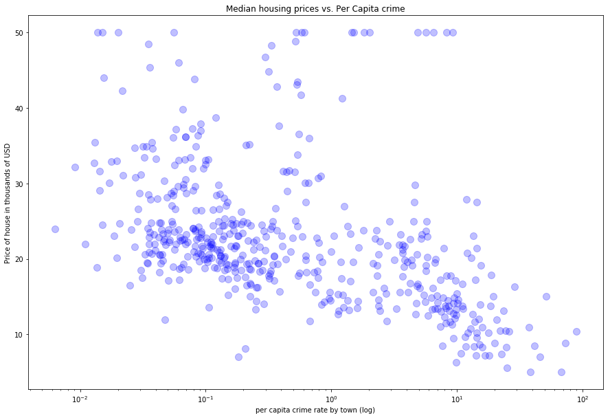

```python
plt.figure(figsize=(15,10))
plt.xlabel("per capita crime rate by town (log)")
plt.ylabel("Price of house in thousands of USD")
plt.title("Median housing prices vs. Per Capita crime")
plt.xscale('log')
plt.scatter(df['CRIM'], df['PRICE'], facecolor='blue', alpha = 0.25, s = 100)
plt.show()
```

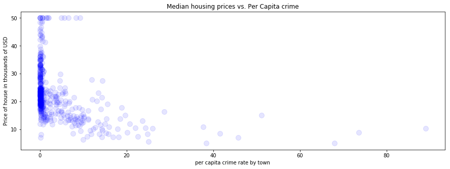

```python
plt.figure(figsize=(15,5))
plt.xlabel("per capita crime rate by town")
plt.ylabel("Price of house in thousands of USD")
plt.title("Median housing prices vs. Per Capita crime")
plt.scatter(df['CRIM'], df['PRICE'], facecolor='blue', alpha = 0.1, s = 100)
plt.show()
```

### 4.2 So many scatterplots!

Choose 8 out of the 14 features of the housing data that you think are most interesting to study. Create an 8x8 grid of scatterplots showing how each of these variables relate to each other. You want to produce something that looks generally like [this image](http://iogas.net/wp-content/gallery/iogas-evaluation/scatterplot-matrix-point-density.png).

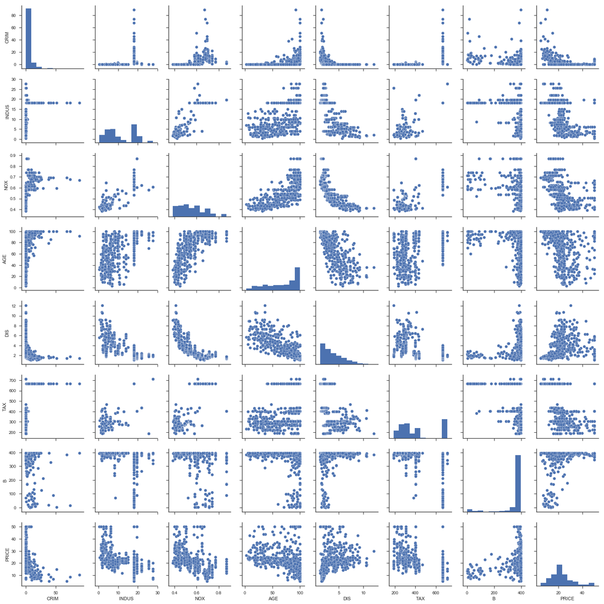

```python
#plt.figure(figsize=(12,12))
#for i in xrange(8):
#    for j in xrange(8):
#        plt.subplot(8, 8, i * 8 + j + 1)
        # insert your code here
import seaborn as sns
sns.set(style="ticks")

sns.pairplot(df.drop(columns=['ZN','CHAS','LSTAT','RAD','RM','PTRATIO']))
plt.show()
```

### 4.3 PCA to the rescue

Run principal component analysis using [PCA](http://scikit-learn.org/stable/modules/generated/sklearn.decomposition.PCA.html) from sklearn to find the first 12 principal components of your data. Use only your training set (66% of the data), and use all features *except* the median housing price. Create a figure showing how the amount of variance explained by your components increases as you increase the number of components from 1 to 12.

```python
# Enter your code here
X_train_bh, X_test_bh, y_train_bh, y_test_bh  = train_test_split(df.drop(columns=['PRICE']), df['PRICE'], test_size = 0.66)

for i in range(1, 13):
    pca = PCA(n_components=i)
    pca.fit(X_train_bh)
    #print(pca.explained_variance_)
```

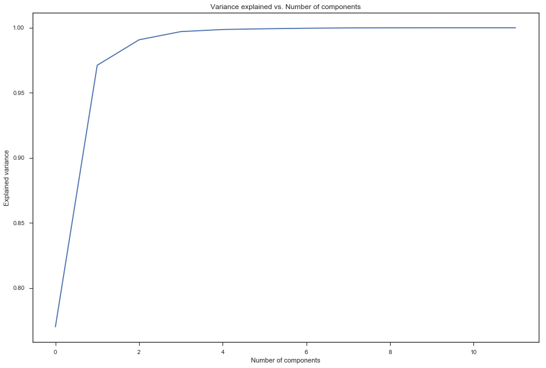

```python
plt.figure(figsize=(15,10))
plt.plot(np.cumsum(pca.explained_variance_ratio_))
plt.xlabel('Number of components')
plt.ylabel('Explained variance')
plt.title('Variance explained vs. Number of components')
plt.show()
```

### 4.4 Visualizing the components

Create a 1X3 grid containing three scatter plots of your training data:

1. PCA 1 vs. PCA 2 (you will need to use `fit_transform` to project your training data onto these two components)
2. PCA 1 (x-axis) vs. median housing value
3. PCA 2 vs. median housing value

```python
# Enter your code here
#pca1 = PCA(n_components=1)
#pca1 = pca1.fit_transform(X_train_bh)
#pca2 = PCA(n_components=2)
#pca2 = pca2.fit_transform(X_train_bh)
```

```python
pca = PCA(n_components=2)
principalComponents = pca.fit_transform(df)
principalDf = pd.DataFrame(data = principalComponents, columns = ['PCA1', 'PCA2'])
```

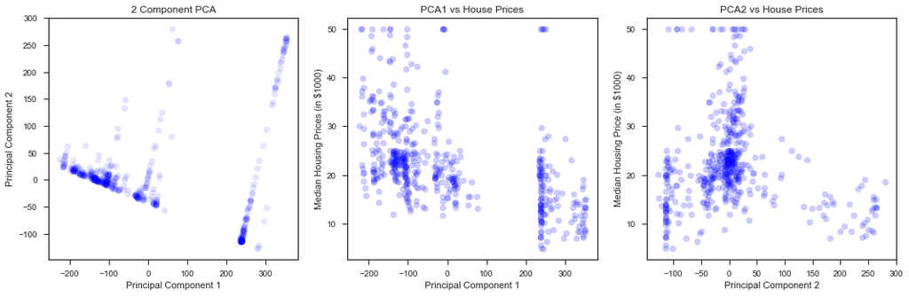

```python
#plt.figure(figsize=(5,5))
plt.figure(figsize=(15, 5))

plt.subplot(1, 3, 1)
plt.scatter(pd.to_numeric(principalDf['PCA1']), pd.to_numeric(principalDf['PCA2']), facecolor = 'blue', alpha = 0.1)
plt.xlabel('Principal Component 1')
plt.ylabel('Principal Component 2')
plt.title('2 Component PCA')
plt.show

plt.subplot(1, 3, 2)
plt.scatter(pd.to_numeric(principalDf['PCA1']), df['PRICE'], facecolor = 'blue', alpha = 0.2)
plt.xlabel('Principal Component 1')
plt.ylabel('Median Housing Prices (in $1000)')
plt.title('PCA1 vs House Prices')
plt.show

plt.subplot(1, 3, 3)
plt.scatter(pd.to_numeric(principalDf['PCA2']), df['PRICE'], facecolor = 'blue', alpha = 0.2)
plt.xlabel('Principal Component 2')
plt.ylabel('Median Housing Price (in $1000)')
plt.title('PCA2 vs House Prices')
plt.show

plt.tight_layout()
```

### 4.5 Regression and PCA

Using just the first Principal Component learned on the training data, project all of your data (including the test data) onto this 1-dimensional subspace using the `fit_transform` function. Now, using your training data, fit a regression of median housing price on this first principal component of your data. Report the RMSE of this regression for both the training and test set. How do these results compare to your results from 4.1? Interpret your results!